# Introduction to Computer Vision: COVID-19 Image Classification

## Problem Statement

### Context

Covid-19 is a fast-growing disease that affects human health severly. Patients diagonised with this condition suffers from lung infection. The medical community has recently released vaccines which have a slower effect in increasing the immunity. This virus has impacted various countries' human health and financial standing.

Deep learning algorithms have recently used image classification to identify medical images. Convolutional Neural Networks (CNN) can be widely utilized to identify COVID-19 to assist radiologists in medical analysis by classifying patients who are healthy, have viral pneumonia, or are affected by COVID using X-ray pictures of the lungs.

### Objective

The aim of this project is to Build a Convolutional Neural Network to differentiate an X-ray image of a person affected with covid from that of a healthy person or a person who has viral pneumonia(fever).

### Data Dictionary

- This dataset contains training set images of 3 classes which are converted into numpy arrays.
- The dataset comprises 3 classes:
  - COVID-19: The patient who is effected due to covid.
  - Viral Pneumonia: This is a viral fever which has similar characteristics like fever and cought that of Covid but is not covid.
  - Normal- A healthy Person with no symptoms of covid or fever.
- The data file names are:
  - CovidImages.npy
  - CovidLabels.csv

#### **Note: Please use GPU runtime to execute the code efficiently**

## Importing necessary libraries

```python
# Installing the libraries with the specified version.
# uncomment and run the following line if Google Colab is being used
!pip install --upgrade matplotlib scikit-learn
```

[output not shown]

```python
!pip install tensorflow==2.15.0 scikit-learn==1.2.2 seaborn==0.13.1 matplotlib==3.7.1 numpy==1.25.2 pandas==1.5.3 opencv-python==4.8.0.76 -q --user --no-deps
```

```python
# Installing the libraries with the specified version.
# uncomment and run the following lines if Jupyter Notebook is being used
#!pip install tensorflow==2.13.0 scikit-learn==1.2.2 seaborn==0.13.1 matplotlib==3.7.1 numpy==1.25.2 pandas==1.5.3 opencv-python==4.8.0.76 -q --user
```

**Note**: *After running the above cell, kindly restart the notebook kernel and run all cells sequentially from the start again.*

```python
import os
import numpy as np                                                                               # Importing numpy for Matrix Operations
import pandas as pd                                                                              # Importing pandas to read CSV files
import matplotlib.pyplot as plt                                                                  # Importing matplotlib for Plotting and visualizing images
import math                                                                                      # Importing math module to perform mathematical operations
import cv2                                                                                       # Importing openCV for image processing
import seaborn as sns                                                                            # Importing seaborn to plot graphs


# Tensorflow modules
import tensorflow as tf
from tensorflow.keras.preprocessing.image import ImageDataGenerator                              # Importing the ImageDataGenerator for data augmentation
from tensorflow.keras.models import Sequential                                                   # Importing the sequential module to define a sequential model
from tensorflow.keras.layers import Dense,Dropout,Flatten,Conv2D,MaxPooling2D,BatchNormalization # Defining all the layers to build our CNN Model
from tensorflow.keras.optimizers import Adam,SGD                                                 # Importing the optimizers which can be used in our model
from sklearn import preprocessing                                                                # Importing the preprocessing module to preprocess the data
from sklearn.model_selection import train_test_split                                             # Importing train_test_split function to split the data into train and test
from sklearn.metrics import confusion_matrix                                                     # Importing confusion_matrix to plot the confusion matrix
from sklearn.preprocessing import LabelBinarizer
# Display images using OpenCV
#from google.colab.patches import cv2_imshow                                                      # Importing cv2_imshow from google.patches to display images
from sklearn.model_selection import train_test_split
from tensorflow.keras import backend
from keras.callbacks import ReduceLROnPlateau
import random
# Ignore warnings
import warnings
warnings.filterwarnings('ignore')
```

## Loading the dataset

```python
# Mount Google drive to access the dataset
# Run the below code if you using google colab
from google.colab import drive
drive.mount('/content/drive')
```

```python
images = np.load('/content/drive/MyDrive/Colab Notebooks/covid 19 deduction/CovidImages-1.npy')
labels = pd.read_csv('/content/drive/MyDrive/Colab Notebooks/covid 19 deduction/CovidLabels.csv')
```

Observation: Google Drive was successfully mounted, enabling access to external datasets stored in the Drive.

## Data Overview

```python
labels.head()
```

|  | Label |
| --- | --- |
| 0 | Viral Pneumonia |
| 1 | Viral Pneumonia |
| 2 | Viral Pneumonia |
| 3 | Viral Pneumonia |
| 4 | Viral Pneumonia |

observation: there is one column of lables.

```python
labels.tail()
```

|  | Label |
| --- | --- |
| 246 | Normal |
| 247 | Normal |
| 248 | Normal |
| 249 | Normal |
| 250 | Normal |

observation: there is one column with different labels.

```python
labels.info()
```

```
<class 'pandas.core.frame.DataFrame'>
RangeIndex: 251 entries, 0 to 250
Data columns (total 1 columns):
 #   Column  Non-Null Count  Dtype
---  ------  --------------  -----
 0   Label   251 non-null    object
dtypes: object(1)
memory usage: 2.1+ KB
```

Observation: The dataset contains 251 rows and 1 column, with no missing values across all.

```python
labels.describe().T
```

|  | count | unique | top | freq |
| --- | --- | --- | --- | --- |
| Label | 251 | 3 | Covid | 111 |

Observation: there are repeated labels and 3 unique values.

```python
labels['Label'].unique()
```

```
array(['Viral Pneumonia', 'Covid', 'Normal'], dtype=object)
```

Observation: there are 3 labels among the data: 'Viral Pneumonia', 'Covid', 'Normal'

```python
labels['Label'].value_counts()
```

|  | Label |
| --- | --- |
| Covid | 111 |
| Viral Pneumonia | 70 |
| Normal | 70 |

**dtype:** int64

Observation: Covid is the top value and 'Viral Pneumonia', and 'Normal' are shown equally

```python
labels.duplicated().sum()
```

```
248
```

observation: it shows there are 248 duplicated labels.

```python
labels.isnull().sum()
```

|  | 0 |
| --- | --- |
| Label | 0 |

**dtype:** int64

observation: there is no null data.

### Understand the shape of the dataset

```python
print(images.shape)
print(labels.shape)
```

```
(251, 128, 128, 3)
(251, 1)
```

- there are 251 images and their dimention are: 128 by 128, and the pixel is 3 color channels (RGB)
- for the labels: there are 251 labels.

## Exploratory Data Analysis

- EDA is an important part of any project involving data.
- It is important to investigate and understand the data better before building a model with it.
- A few questions have been mentioned below which will help you understand the data better.
- A thorough analysis of the data, in addition to the questions mentioned below, should be done.
1. How are these different category X-ray images different from each other?
2. Is the dataset provided an imbalance? (Check with using bar plots)

```python
#first lets plot images randomly from each class.
def plot_images(images,labels):
  num_classes=10
  categories=np.unique(labels)
  keys=dict(labels['Label'])
  rows = 3
  cols = 4
  fig = plt.figure(figsize=(10, 8))
  for i in range(cols):
      for j in range(rows):
          random_index = np.random.randint(0, len(labels))
          ax = fig.add_subplot(rows, cols, i * rows + j + 1)
          ax.imshow(images[random_index, :])
          ax.set_title(keys[random_index])
  plt.show()
```

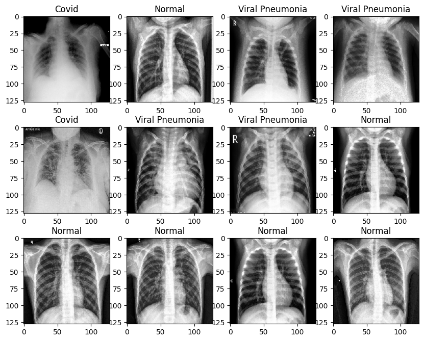

```python
plot_images(images, labels)
```

observation: these images showcase the covid, normal, vs viral pneumonia.

```python
#second let's check the distribution of the target variable
import seaborn as sns
import matplotlib.pyplot as plt
```

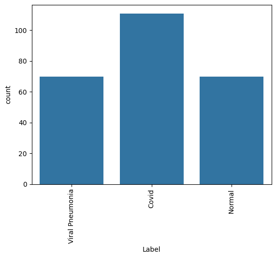

```python
sns.countplot(x=labels['Label'])
plt.xticks(rotation='vertical')
plt.show()
```

observation: this plot shoe the covid being the highest.

## Data Pre-Processing

### Converting the BGR images to RGB images

```python
# using cvtColor function of OpenCV
for i in range(len(images)):
  images[i] = cv2.cvtColor(images[i], cv2.COLOR_BGR2RGB)
```

### Resize the images

As the size of the images is large, it may be computationally expensive to train on these larger images; therefore, it is preferable to reduce the image size from 128 to 64.

```python
images_decreased=[]
height = 64
width = 64
dimensions = (width, height)
for i in range(len(images)):
  images_decreased.append( cv2.resize(images[i], dimensions, interpolation=cv2.INTER_LINEAR))
```

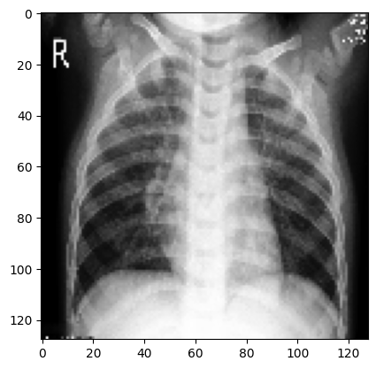

```python
#lets check for before and after resizing
plt.imshow(images[0])
```

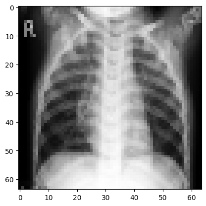

```python
plt.imshow(images_decreased[0])
```

observation: we can see that the images has succeffuly decreased.

### Data Preparation for Modeling

- Before you proceed to build a model, you need to split the data into train, test, and validation to be able to evaluate the model that you build on the train data
- You'll have to encode categorical features and scale the pixel values.
- You will build a model using the train data and then check its performance

**Split the dataset**

```python
X_train, X_test, y_train, y_test = train_test_split(np.array(images_decreased), np.array(labels), test_size=0.1, random_state=42, stratify=labels)
```

### Encode the target labels

```python
#to convert labels from objects to hot vectors by using labelBinarizer method.

from sklearn.preprocessing import LabelBinarizer
enc = LabelBinarizer()
y_train_enc = enc.fit_transform(y_train)
y_test_enc = enc.fit_transform(y_test)
```

```python
y_train_enc.shape
y_test_enc.shape
```

```
(26, 3)
```

### Data Normalization

```python
train_normalized=X_train.astype('float32')/255.0
test_normalized=X_test.astype('float32')/255.0
```

Observation: To normalize the image pixel values (which range from 0 to 255), we'll scale them by dividing each pixel value by 255. This will standardize the images to have values between 0 and 1 for both the training and test sets.

## Model Building

```python
#first lets clear backend
backend.clear_session()
```

```python
#next is to fix the seed for random number generators
np.random.seed(42)
random.seed(42)
tf.random.set_seed(42)
```

```python
#building a sequential model
model1 = Sequential()
model1.add(Conv2D(128, kernel_size=(3, 3), activation='relu', input_shape=(64, 64, 3)))
model1.add(MaxPooling2D(pool_size=(2, 2),padding='same'))
model1.add(Conv2D(64, kernel_size=(3, 3), activation='relu', padding='same'))
model1.add(MaxPooling2D(pool_size=(2, 2),padding='same'))
model1.add(Conv2D(32, kernel_size=(3, 3), activation='relu', padding='same'))
model1.add(MaxPooling2D(pool_size=(2, 2),padding='same'))
model1.add(Flatten())
model1.add(Dense(64, activation='relu'))
model1.add(Dropout(0.5))
model1.add(Dense(3, activation='softmax'))

opt=Adam()
model1.compile(loss='categorical_crossentropy', optimizer=opt, metrics=['accuracy'])
model1.summary()
```

```
Model: "sequential"
_________________________________________________________________
 Layer (type)                Output Shape              Param #
=================================================================
 conv2d (Conv2D)             (None, 62, 62, 128)       3584

 max_pooling2d (MaxPooling2  (None, 31, 31, 128)       0
 D)

 conv2d_1 (Conv2D)           (None, 31, 31, 64)        73792

 max_pooling2d_1 (MaxPoolin  (None, 16, 16, 64)        0
 g2D)

 conv2d_2 (Conv2D)           (None, 16, 16, 32)        18464

 max_pooling2d_2 (MaxPoolin  (None, 8, 8, 32)          0
 g2D)

 flatten (Flatten)           (None, 2048)              0

 dense (Dense)               (None, 64)                131136

 dropout (Dropout)           (None, 64)                0

 dense_1 (Dense)             (None, 3)                 195

=================================================================
Total params: 227171 (887.39 KB)
Trainable params: 227171 (887.39 KB)
Non-trainable params: 0 (0.00 Byte)
_________________________________________________________________
```

Observation: our model architecture:

- Input: Images with dimensions 64x64 pixels and 3 color channels.
- Convolutional Layers: Three convolutional layers with 128, 64, and 32 filters, respectively. Each layer uses 3x3 kernels and ReLU activation.
- Max Pooling Layers: Three max-pooling layers follow each convolutional layer to downsample the feature maps.
- Flatten Layer: Flattens the 3D feature maps into a 1D vector.
- Fully Connected Layers: Two fully connected layers, one with 64 units and another with 3 units (likely for a 3-class classification problem).
- Dropout Layer: A dropout layer is used to prevent overfitting.

```python
#fitting the model on the train data
history1=model1.fit(train_normalized, y_train_enc, epochs=30, validation_split=0.1, shuffle= False, batch_size=64, verbose=1)
```

Observation: the model was successfully fitted on the train data.

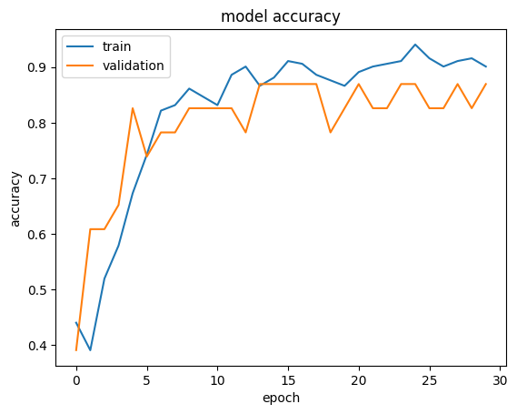

```python
#now we evaluate our model
plt.plot(history1.history['accuracy'])
plt.plot(history1.history['val_accuracy'])
plt.title('model accuracy')
plt.ylabel('accuracy')
plt.xlabel('epoch')
plt.legend(['train', 'validation'], loc='upper left')
plt.show()
```

```python
#evaluating on test data
model1.evaluate(test_normalized, y_test_enc, verbose=1)
```

```
[0.16125719249248505, 0.9230769276618958]
```

observation: model accuracy on test data showed 92%

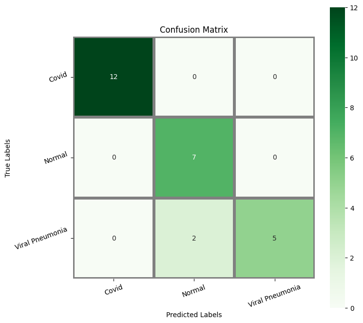

```python
#plotting the confusion matrix
y_pred=model1.predict(test_normalized)
y_pred_classes = np.argmax(y_pred, axis=1)
y_test_classes = np.argmax(y_test_enc, axis=1)
cm = confusion_matrix(y_test_classes, y_pred_classes)
f,ax = plt.subplots(figsize=(8, 8))
sns.heatmap(cm, annot=True, linewidths=4,cmap="Greens",linecolor="gray", fmt= 'd',square= True, ax=ax)
ax.set_xlabel('Predicted Labels');ax.set_ylabel('True Labels');
ax.set_title('Confusion Matrix');
ax.xaxis.set_ticklabels(['Covid', 'Normal', 'Viral Pneumonia'], rotation=20); ax.yaxis.set_ticklabels(['Covid', 'Normal', 'Viral Pneumonia'], rotation=20);
plt.show()
```

onbservation: The confusion matrix shows the model's performance in classifying Covid, Normal, and Viral Pneumonia cases. It indicates good accuracy for Covid and Normal, with some misclassifications between Normal and Viral Pneumonia.

```python
#lets plot the classification report
from sklearn.metrics import classification_report
print(classification_report(y_test_classes, y_pred_classes))
```

```
              precision    recall  f1-score   support

           0       1.00      1.00      1.00        12
           1       0.78      1.00      0.88         7
           2       1.00      0.71      0.83         7

    accuracy                           0.92        26
   macro avg       0.93      0.90      0.90        26
weighted avg       0.94      0.92      0.92        26
```

observation: The model shows strong performance overall, with high accuracy of 92% and good precision and recall for most classes. Class 2 (likely Viral Pneumonia) has slightly lower recall, indicating that some instances of this class might be misclassified.

## Model Performance Improvement

**Reducing the Learning Rate:**

**Hint**: Use **ReduceLRonPlateau()** function that will be used to decrease the learning rate by some factor, if the loss is not decreasing for some time. This may start decreasing the loss at a smaller learning rate. There is a possibility that the loss may still not decrease. This may lead to executing the learning rate reduction again in an attempt to achieve a lower loss.

```python
learning_rate_reduction = ReduceLROnPlateau(monitor='val_accuracy',
                                            patience=2,
                                            verbose=1,
                                            factor=0.5,
                                            min_lr=0.00001)
```

### **Data Augmentation**

Remember, **data augmentation should not be used in the validation/test data set**.

```python
from tensorflow.keras import backend
backend.clear_session()
import random
np.random.seed(42)
random.seed(42)
tf.random.set_seed(42)
```

```python
# now lets rescale images by 1/255
train_datagen = ImageDataGenerator(rotation_range= 20, fill_mode= 'nearest')
test_datagen = ImageDataGenerator(rescale=1.0/255.0)
```

```python
model2 = Sequential()
model2.add(Conv2D(64, kernel_size=(3, 3), activation='relu', input_shape=(64, 64, 3)))
model2.add(MaxPooling2D(pool_size=(2, 2),padding='same'))
model2.add(Conv2D(32, kernel_size=(3, 3), activation='relu', padding='same'))
model2.add(MaxPooling2D(pool_size=(2, 2),padding='same'))
model2.add(BatchNormalization())
model2.add(Flatten())
model2.add(Dense(16, activation='relu'))
model2.add(Dropout(0.5))
model2.add(Dense(3, activation='softmax'))

opt=Adam()
model2.compile(loss='categorical_crossentropy', optimizer=opt, metrics=['accuracy'])
model2.summary()
```

```
Model: "sequential"
_________________________________________________________________
 Layer (type)                Output Shape              Param #
=================================================================
 conv2d (Conv2D)             (None, 62, 62, 64)        1792

 max_pooling2d (MaxPooling2  (None, 31, 31, 64)        0
 D)

 conv2d_1 (Conv2D)           (None, 31, 31, 32)        18464

 max_pooling2d_1 (MaxPoolin  (None, 16, 16, 32)        0
 g2D)

 batch_normalization (Batch  (None, 16, 16, 32)        128
 Normalization)

 flatten (Flatten)           (None, 8192)              0

 dense (Dense)               (None, 16)                131088

 dropout (Dropout)           (None, 16)                0

 dense_1 (Dense)             (None, 3)                 51

=================================================================
Total params: 151523 (591.89 KB)
Trainable params: 151459 (591.64 KB)
Non-trainable params: 64 (256.00 Byte)
_________________________________________________________________
```

```python
#fitting the model on train data
epochs=30
batch_size=64
history2=model2.fit(train_datagen.flow(train_normalized, y_train_enc, batch_size=batch_size, shuffle=False),
                    epochs=epochs,
                    steps_per_epoch=train_normalized.shape[0] // batch_size,
                    validation_data=(test_normalized, y_test_enc),
                    verbose=1,
                    callbacks=[learning_rate_reduction])
```

```
Epoch 3: ReduceLROnPlateau reducing learning rate to 0.0005000000237487257.
Epoch 5: ReduceLROnPlateau reducing learning rate to 0.0002500000118743628.
Epoch 7: ReduceLROnPlateau reducing learning rate to 0.0001250000059371814.
Epoch 9: ReduceLROnPlateau reducing learning rate to 6.25000029685907e-05.
Epoch 11: ReduceLROnPlateau reducing learning rate to 3.125000148429535e-05.
Epoch 13: ReduceLROnPlateau reducing learning rate to 1.5625000742147677e-05.
Epoch 18: ReduceLROnPlateau reducing learning rate to 1e-05.
```

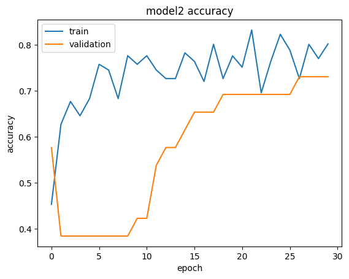

```python
#model evaluation
plt.plot(history2.history['accuracy'])
plt.plot(history2.history['val_accuracy'])
plt.title('model2 accuracy')
plt.ylabel('accuracy')
plt.xlabel('epoch')
plt.legend(['train', 'validation'], loc='upper left')
plt.show()
```

Observation: The graph shows the training and validation accuracy of a machine learning model over 30 epochs. The training accuracy fluctuates, while the validation accuracy plateaus after around 20 epochs, suggesting potential overfitting.

```python
#evaluation model2 on test data
model2.evaluate(test_normalized, y_test_enc, verbose=1)
```

```
[0.8793506622314453, 0.7307692170143127]
```

observation: model 2 has 73% accuracy

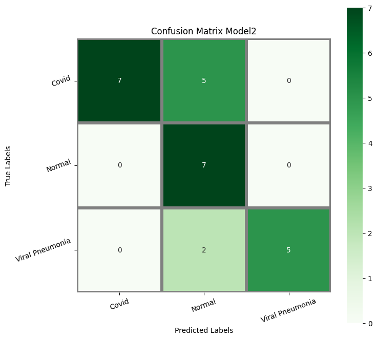

```python
#plotting the confusion matrix
y_pred=model2.predict(test_normalized)
y_pred_classes = np.argmax(y_pred, axis=1)
y_test_classes = np.argmax(y_test_enc, axis=1)
cm = tf.math.confusion_matrix(y_test_classes, y_pred_classes)
f,ax = plt.subplots(figsize=(8, 8))
sns.heatmap(cm, annot=True, linewidths=4,cmap="Greens",linecolor="gray", fmt= 'd',square= True, ax=ax)
ax.set_xlabel('Predicted Labels');ax.set_ylabel('True Labels');
ax.set_title('Confusion Matrix Model2');
ax.xaxis.set_ticklabels(['Covid', 'Normal', 'Viral Pneumonia'], rotation=20); ax.yaxis.set_ticklabels(['Covid', 'Normal', 'Viral Pneumonia'], rotation=20);
plt.show()
```

```python
#plotting the classification report
print(classification_report(y_test_classes, y_pred_classes))
```

```
              precision    recall  f1-score   support

           0       1.00      0.58      0.74        12
           1       0.50      1.00      0.67         7
           2       1.00      0.71      0.83         7

    accuracy                           0.73        26
   macro avg       0.83      0.77      0.75        26
weighted avg       0.87      0.73      0.74        26
```

observation: Model 2 demonstrates an overall accuracy of 0.73. While it achieves perfect precision for classes 0 and 2, recall for class 0 is relatively low at 0.58, suggesting potential misclassification of some class 0 instances.

## Final Model

Comment on the final model you have selected and use the same in the below code to visualize the image.

```python
# I select the first model
```

### Visualizing the prediction

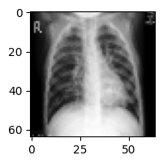

```
Predicted Label ['Viral Pneumonia']
True Label ['Viral Pneumonia']
```

```python
plt.figure(figsize=(2, 2))
plt.imshow(test_normalized[0])
plt.show()
print('Predicted Label', enc.inverse_transform(model1.predict(test_normalized[0].reshape(1, 64, 64, 3))))
print('True Label',enc.inverse_transform( y_test_enc[0].reshape(1, -1)))
```

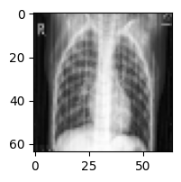

```
Predicted Label ['Viral Pneumonia']
True Label ['Viral Pneumonia']
```

```python
plt.figure(figsize=(2, 2))
plt.imshow(test_normalized[10])
plt.show()
print('Predicted Label', enc.inverse_transform(model1.predict(test_normalized[10].reshape(1, 64, 64, 3))))
print('True Label',enc.inverse_transform( y_test_enc[10].reshape(1, -1)))
```

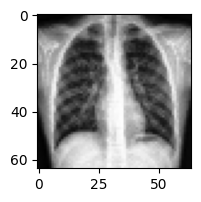

```
Predicted Label ['Normal']
True Label ['Normal']
```

```python
plt.figure(figsize=(2,2))
plt.imshow(test_normalized[20])
plt.show()
print('Predicted Label', enc.inverse_transform(model1.predict(test_normalized[20].reshape(1, 64, 64, 3))))
print('True Label',enc.inverse_transform( y_test_enc[20].reshape(1, -1)))
```

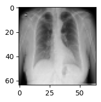

```
Predicted Label ['Covid']
True Label ['Covid']
```

```python
plt.figure(figsize=(2,2))
plt.imshow(test_normalized[5])
plt.show()
print('Predicted Label', enc.inverse_transform(model1.predict(test_normalized[5].reshape(1, 64, 64, 3))))
print('True Label',enc.inverse_transform( y_test_enc[5].reshape(1, -1)))
```

## Actionable Insights and Business Recommendations

- Actionable Insights:
1. Increasing the number of Viral Pneumonia images in the training dataset is needed to improve covid 19 detection.
2. Testing the model on a larger and more diverse dataset to assess its generalizability and robustness in real-world scenarios. This will help identify potential biases or limitations.
- Business Recommendations:
1. Implement a continuous learning framework to update the model with new data and improve its performance over time. This will ensure that the model remains accurate and relevant in the evolving landscape of the pandemic.
2. Investigate methods to explain the model's predictions. This will increase trust and enable better understanding of the model's decision-making process.
3. Partner with healthcare professionals to validate the model's performance in real-world clinical settings and obtain valuable feedback for further improvement.

```python
#to download the html
import nbconvert
```

```python
!jupyter nbconvert --to html /content/COVID_19_Dedection_Project_AlaaAlzahrani.ipynb
```

[output not shown]

[output cut: 136 more lines]

[output not shown]